# RNASeq data processing

Hailey Hatch & Maggie Sogin

2026-11-12

# Introduction

This notebook processes metatranscriptomic (RNA-seq) data from an *Aiptasia* bacterial inoculation experiment. *Aiptasia* were first treated with antibiotics to reduce their native microbiome, then inoculated with one of three bacterial symbionts to examine changes in host, algal symbiont, and bacterial gene expression.

The script below aims to process data from RNA-Seq experiment and includes the following:

1. Load in data
2. Get Counts from featurecounts (saved)
3. Get TPM Counts (not saved)
4. QC plots
5. Clean and split tables, save by organism
6. Prepare annotations

**Previous pipeline:** Raw reads were processed with fastp (quality trimming) → SortMeRNA (rRNA removal) → HISAT2 (alignment to a combined reference genome containing *Aiptasia* host, *Symbiodiniaceae* symbiont, *Labrenzia*, *Ruegeria*, and *Vibrio*) → featureCounts (gene-level quantification).

# 1. Load Libraries & Define Constants

```r
library(readxl)
library(tidyverse)
library(DESeq2)
library(ggplot2)
library(pheatmap)
library(matrixStats)
library(ggrepel)
library(patchwork)
library(UpSetR)
library(stringr)
library(topGO)
library(vegan)
library(dplyr)
library("RColorBrewer")
library(scales)
```

```r
palette <- c(
  "FASW" = 'grey60',
  "ABS"     = 'black',
  "Labrenzia"    = '#A6CEE3',
  "Ruegeria"    = '#1F78B4',
  "Vibrio"    = '#B2DF8A',
  "multi"  = 'violet')
treatment_levels <- c(
  "control" = "FASW",
  "ABS" = "ABS",
  "ISOA" = "Labrenzia",
  "ISOB" = "Ruegeria",
  "ISOC" = "Vibrio",
  "ISOABC" = "multi")

path.out<-"../../output/transcriptomics_v3"
path.in<-"../../data/transcriptomics_v2"
```

# 2. Load All Data Files

```r
# featureCounts gene count matrix (6 annotation cols + 48 samples), have for V2
counts_raw <- read.delim(file.path(path.in,"counts.tsv"), comment.char = "#", check.names = FALSE)

# featureCounts assignment summary, have for V2
counts_summary <- read.delim(file.path(path.in,"counts.tsv.summary"), check.names = FALSE)

# HISAT2 alignment rates, have for V2
hisat2_sum <- read.delim(file.path(path.in,"hisat2_alignment_summary.tsv"))

# Per-reference organism read counts (aip, sym, lab, rue, vib), have for V2
organism_counts <- read.delim(file.path(path.in,"per_reference_counts.tsv"))

# SortMeRNA rRNA removal summary --> NEED
sortme_sum <- read.delim(file.path(path.in,"sortmerrna_summary.tsv")) #can't find this

# Fastp trimming summary --> NEED
fastp_sum <- read.delim(file.path(path.in,"fastp_summary_per_sample.tsv"), check.names = FALSE) #can't find this

# Aiptasia gene annotations (SwissProt/TrEMBL BLAST, GO, KEGG)
aip_annotate <- read.delim(file.path(path.in,"aiptasia_annotation_file.tsv")) #have this
length(aip_annotate$Protein_ID)
```

```
## [1] 29269
```

# 3. Build Sample Metadata

Create the `colData` data frame that DESeq2 requires. We’ll parse treatment and timepoint directly from the sample names so it’s fully reproducible.

```r
# Step 1: Make function to clean sample names
clean_sample_name <- function(x) {gsub("_S\\d+.*$", "", x)}

# Step 2: Get sample column names from the counts data
colnames(counts_raw) <- clean_sample_name(basename(colnames(counts_raw)))
annotation_cols <- c("Geneid", "Chr", "Start", "End", "Strand", "Length")
sample_names <- colnames(counts_raw)[!colnames(counts_raw) %in% annotation_cols]

# Step 3: Parse treatment and timepoint from the clean names
treatment <- str_extract(sample_names, "ISOABC|ISOA|ISOB|ISOC|ABS|control")
timepoint <- str_extract(sample_names, "\\d+dpi")

# Step 4: Create the colData data frame
colData <- data.frame(row.names = sample_names, treatment = treatment, timepoint = timepoint)

# Step 5: Convert treatment and timepoint to factors with your defined levels
colData$treatment <- factor(treatment_levels[as.character(colData$treatment)],
                            levels = treatment_levels)
colData$timepoint <- factor(colData$timepoint, levels = c("1dpi", "21dpi"))

stopifnot(all(table(colData$treatment, colData$timepoint) == 4))

# Make metadata by turning rownames into a regular column
metadata <- colData %>% rownames_to_column("sample")

# save colData

write.csv(colData, file.path(path.out,'colData.csv'))
```

# 4. QC Summary Plots

Visualize pipeline quality metrics to identify any problematic samples before DESeq2.

## 4.1 Fastp — Read Quality & Trimming

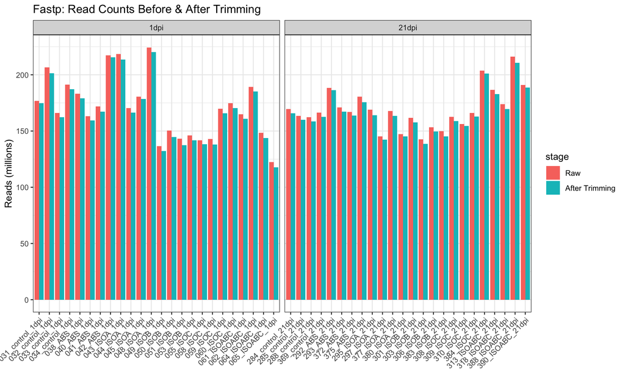

```r
plot_QC_fastp <- fastp_sum %>%
  mutate(sample = clean_sample_name(sample)) %>%
  left_join(metadata, by = "sample") %>%
  filter(!is.na(treatment)) %>%
  arrange(treatment, timepoint) %>%
  mutate(sample = fct_inorder(sample)) %>%
  dplyr::select(sample, treatment, timepoint, reads_before, reads_after) %>%
  pivot_longer(cols = c(reads_before, reads_after),
               names_to = "stage", values_to = "reads") %>%
  mutate(stage = factor(stage, levels = c("reads_before", "reads_after"),
                        labels = c("Raw", "After Trimming"))) %>%
  ggplot(aes(x = sample, y = reads / 1e6, fill = stage)) +
  geom_col(position = "dodge") +
  facet_wrap(~ timepoint, scales = "free_x") +
  theme_bw() +
  theme(axis.text.x = element_text(angle = 45, hjust = 1)) +
  labs(title = "Fastp: Read Counts Before & After Trimming",
       y = "Reads (millions)", x = NULL)
plot_QC_fastp
```

```r
# No extreme trimming; all samples ~125-225M reads
```

## 4.2 SortMeRNA — rRNA Removal Rates

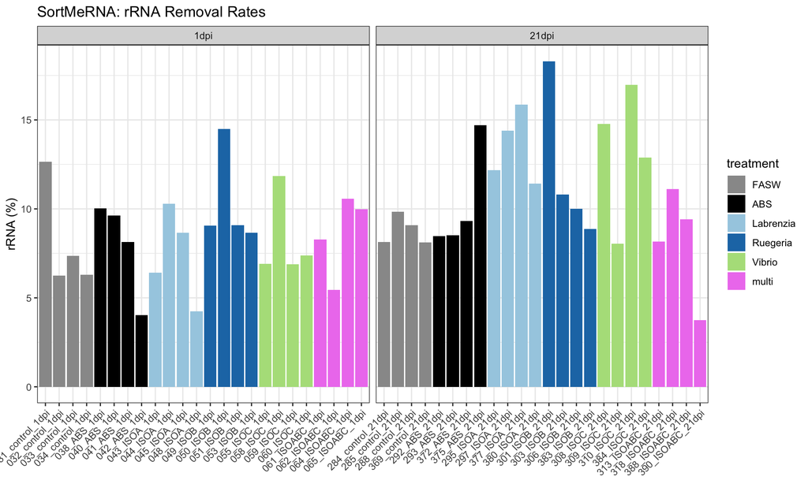

```r
plot_QC_sortmerna <- sortme_sum %>%
  mutate(sample = clean_sample_name(sample)) %>%
  left_join(metadata, by = "sample") %>%
  arrange(treatment, timepoint) %>%
  mutate(sample = fct_inorder(sample)) %>%
  ggplot(aes(x = sample, y = rRNA_pct, fill = treatment)) +
  geom_col() +
  facet_wrap(~ timepoint, scales = "free_x") +
  scale_fill_manual(values = palette) +
  theme_bw() +
  theme(axis.text.x = element_text(angle = 45, hjust = 1)) +
  labs(title = "SortMeRNA: rRNA Removal Rates", y = "rRNA (%)", x = NULL)
plot_QC_sortmerna
```

```r
# ~5-20% rRNA; 21dpi slightly higher on average
```

## 4.3 HISAT2 — Alignment Rates

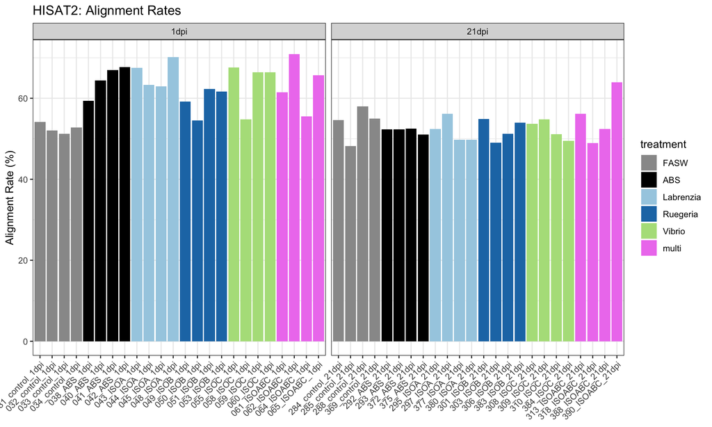

```r
plot_QC_hisat2 <- hisat2_sum %>%
  mutate(sample = clean_sample_name(sample)) %>%
  left_join(metadata, by = "sample") %>%
  arrange(treatment, timepoint) %>%
  mutate(sample = fct_inorder(sample)) %>%
  ggplot(aes(x = sample, y = `overall_alignment_rate...`, fill = treatment)) +
  geom_col() +
  facet_wrap(~ timepoint, scales = "free_x") +
  scale_fill_manual(values = palette) +
  theme_bw() +
  theme(axis.text.x = element_text(angle = 45, hjust = 1)) +
  labs(title = "HISAT2: Alignment Rates", y = "Alignment Rate (%)", x = NULL)
plot_QC_hisat2
```

```r
# Alignment rates 50-75%
```

## 4.4 % Library Mapped to Each Genome

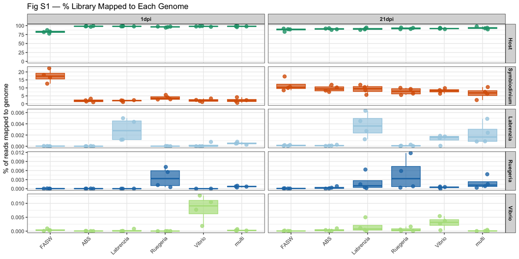

```r
# Compute % of total mapped reads assigned to each organism per sample
plot.df <- organism_counts %>%
  mutate(sample = clean_sample_name(sample)) %>%
  left_join(metadata, by = "sample") %>%
  mutate(total = aip + sym + lab + rue + vib) %>%
  pivot_longer(cols = c(aip, sym, lab, rue, vib),
               names_to = "organism", values_to = "reads") %>%
  mutate(pct_mapped = 100 * reads / total,
         organism = factor(organism,
                           levels = c("aip", "sym", "lab", "rue", "vib"),
                           labels = c("Host", "Symbiodinium", "Labrenzia", "Ruegeria", "Vibrio")),
         treatment = factor(treatment, levels = treatment_levels))

plot_figS1 <- ggplot(plot.df, aes(x = treatment, y = pct_mapped, color = organism, fill=organism)) +
  geom_boxplot(outlier.shape = NA, alpha = 0.7) +
  geom_jitter(width = 0.2, size = 2.5, alpha = 0.8) +
  facet_grid(organism ~ timepoint, scales = "free_y") +
  scale_color_manual(values = c("Host" = "#1b9e77", "Symbiodinium" = "#d95f02",
                                "Labrenzia" = "#A6CEE3", "Ruegeria" = "#1F78B4",
                                "Vibrio" = "#B2DF8A")) +
  scale_fill_manual(values = c("Host" = "#1b9e77", "Symbiodinium" = "#d95f02",
                                "Labrenzia" = "#A6CEE3", "Ruegeria" = "#1F78B4",
                                "Vibrio" = "#B2DF8A")) +
  ylim(0, NA) +
  theme_bw() +
  theme(axis.text.x = element_text(angle = 45, hjust = 1),
        legend.position = "none",
        strip.text = element_text(face = "bold")) +
  labs(title = "Fig S1 — % Library Mapped to Each Genome",
       y = "% of reads mapped to genome", x = NULL)

plot_figS1
```

```r
#ggsave(file.path(path.out,"Fig_pct_mapped_by_genome.pdf"), plot_figS1, width = 12, height = 6)
#ggsave(file.path(path.out,"Fig_pct_mapped_by_genome.png"), plot_figS1, width = 12, height = 6, dpi = 300)
```

```r
organism_counts
```

```
##                      sample       aip      sym  lab  rue   vib
## 1    031_control_1dpi_S2_fp  81401609 11798295   44   76   895
## 2    032_control_1dpi_S3_fp  94017750 20827098   64   22    84
## 3    033_control_1dpi_S4_fp  69488164 19956070    0   30   302
## 4    034_control_1dpi_S5_fp  89359119 17734830    2    4   359
## 5        038_ABS_1dpi_S6_fp 100478750  3352000   56   60    41
## 6        040_ABS_1dpi_S7_fp  99124042  2209880   10   20    89
## 7        041_ABS_1dpi_S8_fp 109454382  1659878    8   27    62
## 8        042_ABS_1dpi_S9_fp 158454958  1658804    2   16    31
## 9      043_ISOA_1dpi_S10_fp 144037574  3151254 1714    4     4
## 10     044_ISOA_1dpi_S11_fp 101105338  2379118 4501   31   872
## 11     045_ISOA_1dpi_S12_fp 108699011  2225720 1327    2    69
## 12     048_ISOA_1dpi_S13_fp 164672354  1944289 8320    0    42
## 13     049_ISOB_1dpi_S14_fp  73662036  4364453   40 5615    26
## 14     050_ISOB_1dpi_S15_fp  70050395  2976932   24 4029    13
```

[output cut: 34 more lines]

```r
write.csv(organism_counts, file.path(path.out,'organism_mapping_counts.csv'))
```

```r
plot.df
```

```
## # A tibble: 240 × 7
##    sample           treatment timepoint     total organism      reads pct_mapped
##    <chr>            <fct>     <fct>         <int> <fct>         <int>      <dbl>
##  1 031_control_1dpi FASW      1dpi       93200919 Host         8.14e7 87.3
##  2 031_control_1dpi FASW      1dpi       93200919 Symbiodinium 1.18e7 12.7
##  3 031_control_1dpi FASW      1dpi       93200919 Labrenzia    4.4 e1  0.0000472
##  4 031_control_1dpi FASW      1dpi       93200919 Ruegeria     7.6 e1  0.0000815
##  5 031_control_1dpi FASW      1dpi       93200919 Vibrio       8.95e2  0.000960
##  6 032_control_1dpi FASW      1dpi      114845018 Host         9.40e7 81.9
##  7 032_control_1dpi FASW      1dpi      114845018 Symbiodinium 2.08e7 18.1
##  8 032_control_1dpi FASW      1dpi      114845018 Labrenzia    6.4 e1  0.0000557
##  9 032_control_1dpi FASW      1dpi      114845018 Ruegeria     2.2 e1  0.0000192
## 10 032_control_1dpi FASW      1dpi      114845018 Vibrio       8.4 e1  0.0000731
## # ℹ 230 more rows
```

```r
write.csv(plot.df, file.path(path.out,'percent_mapped_persample.csv'))
```

```r
# Mean % Symbiodinium reads per treatment x timepoint
symb_means <- plot.df %>%
  filter(organism == "Symbiodinium") %>%
  group_by(timepoint, treatment) %>%
  summarise(mean_pct = mean(pct_mapped, na.rm = TRUE), .groups = "drop")

# Fold change for every treatment pair within each timepoint
symb_fc <- inner_join(symb_means, symb_means, by = "timepoint",
                      suffix = c("_1", "_2"),
                      relationship = "many-to-many") %>%
  filter(as.integer(treatment_1) < as.integer(treatment_2)) %>%
  mutate(FC     = mean_pct_1 / mean_pct_2,
         log2FC = log2(FC))

symb_fc
```

```
## # A tibble: 30 × 7
##    timepoint treatment_1 mean_pct_1 treatment_2 mean_pct_2    FC  log2FC
##    <fct>     <fct>            <dbl> <fct>            <dbl> <dbl>   <dbl>
##  1 1dpi      FASW             17.4  ABS               1.98 8.78   3.13
##  2 1dpi      FASW             17.4  Labrenzia         1.90 9.15   3.19
##  3 1dpi      FASW             17.4  Ruegeria          3.82 4.56   2.19
##  4 1dpi      FASW             17.4  Vibrio            2.18 7.99   3.00
##  5 1dpi      FASW             17.4  multi             2.20 7.90   2.98
##  6 1dpi      ABS               1.98 Labrenzia         1.90 1.04   0.0605
##  7 1dpi      ABS               1.98 Ruegeria          3.82 0.520 -0.943
##  8 1dpi      ABS               1.98 Vibrio            2.18 0.910 -0.136
##  9 1dpi      ABS               1.98 multi             2.20 0.900 -0.152
## 10 1dpi      Labrenzia         1.90 Ruegeria          3.82 0.499 -1.00
## # ℹ 20 more rows
```

```r
unique(plot.df$treatment)
```

```
## [1] FASW      ABS       Labrenzia Ruegeria  Vibrio    multi
## Levels: FASW ABS Labrenzia Ruegeria Vibrio multi
```

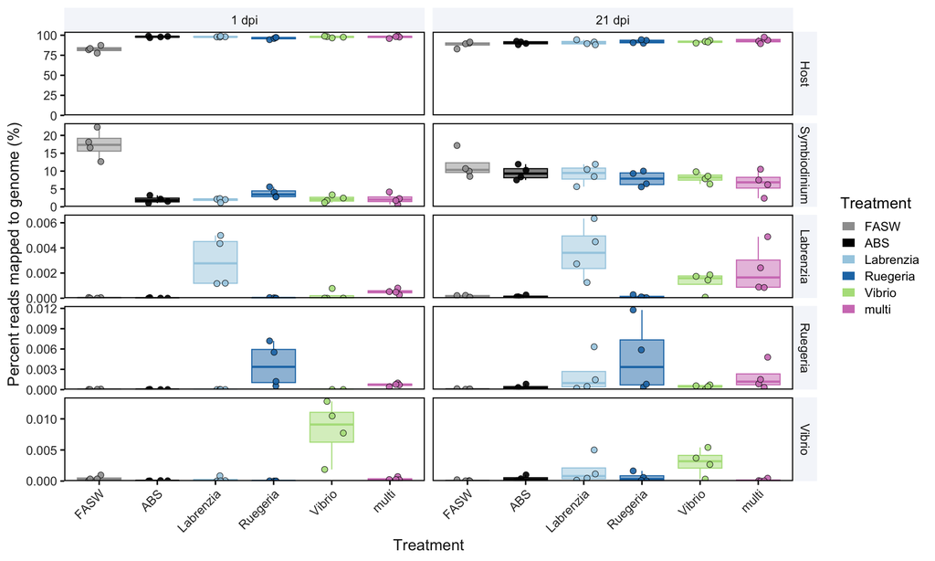

```r
# ---- Project palette & theme ----

treatment_levels <- c("FASW", "ABS", "Labrenzia", "Ruegeria", "Vibrio", "multi")

treatment_cols <- c(
  "FASW"      = "#9E9E9E",
  "ABS"       = "#000000",
  "Labrenzia" = "#A6CEE3",
  "Ruegeria"  = "#1F78B4",
  "Vibrio"    = "#B2DF8A",
  "multi"     = "#D17FBF"
)

theme_project <- function(base_size = 12) {
  theme_classic(base_size = base_size) +
    theme(
      panel.border     = element_rect(color = "black", fill = NA, linewidth = 0.8),
      axis.line        = element_blank(),
      axis.text        = element_text(color = "grey20"),
      axis.title       = element_text(color = "grey10"),
      strip.background = element_rect(fill = "#F5F6FA", color = NA),
      strip.text       = element_text(color = "grey10"),
      legend.title     = element_text(size = base_size),
      legend.key.size  = unit(0.45, "cm"),
      plot.title       = element_text(size = base_size + 1)
    )
}

# ---- Fig S1 ----
plot.df$treatment <- factor(plot.df$treatment, levels = treatment_levels)

# Keep existing timepoints (e.g. "1dpi", "21dpi"), ordered by day number, labelled "1 dpi", "21 dpi"
tp_num <- as.numeric(gsub("\\D", "", plot.df$timepoint))
plot.df$timepoint <- factor(paste(tp_num, "dpi"),
                               levels = paste(sort(unique(tp_num)), "dpi"))

figs3 <- ggplot(plot.df, aes(x = treatment, y = pct_mapped,
                                     color = treatment, fill = treatment)) +
  geom_boxplot(outlier.shape = NA, alpha = 0.5, linewidth = 0.4) +
  geom_jitter(width = 0.2, size = 2, alpha = 0.9, shape = 21, color = "black", stroke = 0.3) +
  facet_grid(organism ~ timepoint, scales = "free_y") +
  scale_color_manual(values = treatment_cols, name = "Treatment") +
  scale_fill_manual(values = treatment_cols, name = "Treatment") +
  scale_y_continuous(limits = c(0, NA), expand = expansion(mult = c(0, 0.05))) +
  theme_project() +
  theme(axis.text.x = element_text(angle = 45, hjust = 1)) +
  guides(color = "none",
         fill = guide_legend(override.aes = list(shape = NA, alpha = 1, color = NA))) +
  labs(y = " Percent reads mapped to genome (%)", x = "Treatment")

figs3
```

```r
ggsave(filename = file.path(path.out,'figureS3.svg'),height=9,width = 8, units="in")
```